# How to write a function that visualizes a spatial point vector attribute over a contrast stretched raster image

Diana Dermann und Daniela Krampe

Wednesday, February 04, 2015

This How-To will explain how to write a function that visualizes a spatial point vector attribute over a contrast stretched raster image.

As always the first steps are to set the working directory and load the required packages.

```r
if (!require(sp)){install.packages('sp')}
if (!require(RColorBrewer)){install.packages('RColorBrewer')}
if (!require(raster)){install.packages('raster')}
if (!require(rgdal)){install.packages('rgdal')}
```

[output not shown]

```r
if (!require(latticeExtra)){install.packages('latticeExtra')}
library(sp)
library(raster)
library(rgdal)
library(RColorBrewer)
library(latticeExtra)
```

Note that the code for the installation of the packages is conditional. “Require” works just the same as “library”, but instead of giving an error if the package is not installed yet, it will return “FALSE”. Therefore the first block will only install the packages if they are not downloaded yet. Library loads the packages.

In the next step we’ll write the function. First you will see the entire function and then the parts it contains will be discussed separately. You will have to know your dataset before you write the function. So it’s a good idea to check the parameters before you start writing the function.

```r
visualizer <- function (raster, vector, palname="Reds",lines){
  vector_classes <- cut(vector@data$NAT, c(0, 2, 4, 6, 8, 10))
  vector_colors <- colorRampPalette(brewer.pal(5,palname))(5)
  min <- max(mean(getValues(raster)) - sd(getValues(raster)), 0)
  max <- mean(getValues(raster)) + sd(getValues(raster))

  breaks <- seq(min, max, length.out = 256)
  yat = seq(extent(raster)@ymin,
            extent(raster)@ymax, length.out = lines)
  xat = seq(extent(raster)@xmin,
            extent(raster)@xmax, length.out = lines)



  abb <- spplot(raster, col.regions = gray.colors(256), at = breaks,
                key = list(space = 'left', text = list(levels(vector_classes)),
                           points = list(pch = 21, cex = 2, fill = vector_colors)),
                colorkey=list(space="right"),
                panel = function(...){
                  panel.levelplot(...)
                  panel.abline(h = yat, v = xat, col = "grey0", lwd = 0.8, lty = 3)
                  }
  )
  Farben <- spplot(vector, zcol = "NAT", col.regions = vector_colors, cuts = c(0, 2, 4, 6, 8, 10))

  abb + as.layer(Farben)
}
```

To create a function define the name of the function and what parameters are required to be put in by the user. In our case the user has to tell the function which raster and which vector are to be used. For the color palette the default value “Reds” is set and if you write a help page for the function it would be important to mention the “” are obligatory and only palettes from brewer.pal can be used. lines will determine the amount of coordinate grid lines on the map. Now we’ll define more necessary parameters for the plot.

```
vector_classes <- cut(vector@data$NAT, c(0, 2, 4, 6, 8, 10))
vector_colors <- colorRampPalette(brewer.pal(5,palname))(5)
```

The classes for the visualization of the vector have to be chosen now. In this case we are using the number of natural species, saved under NAT. As the values range between 0 and 9 the classes range from 0 to 10. The same is done for the raster image in the following code:

```
min <- max(mean(getValues(raster)) - sd(getValues(raster)), 0)
max <- mean(getValues(raster)) + sd(getValues(raster))

breaks <- seq(min, max, length.out = 256)
yat = seq(extent(raster)@ymin,
            extent(raster)@ymax, length.out = lines)
xat = seq(extent(raster)@xmin,
            extent(raster)@xmax, length.out = lines)
```

[output not shown]

```
Farben <- spplot(vector, zcol = "NAT", col.regions = vector_colors, cuts = c(0, 2, 4, 6, 8, 10))
abb + as.layer(Farben)
```

As you can see all that’s left to do is define the plotting parameters of the shapefile and then add the two plots together. Since we created variables for the plotting parameters we can simply put them together with a + and don’t forget to add the shapefile as a layer ontop of the raster with the function as.layer. That’s it. That’s our function.

To see if the works load the Band 3 of the Fogo Landsat image and the shapefile containing the dataset with the number of natural species, check if they are loaded correctly and then run the function.

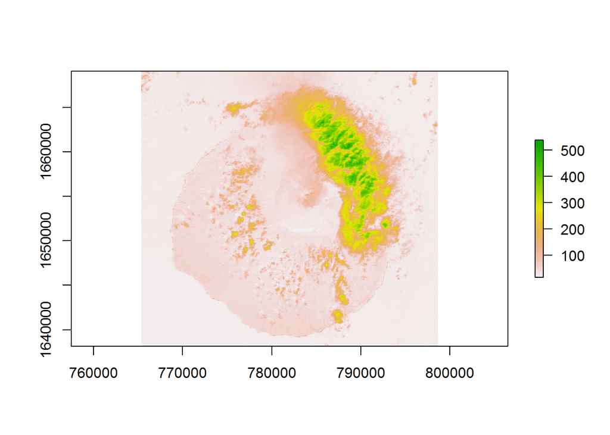

```r
landsat_Kanal3 <- raster("E:/MasterMarburg/Data Management/Data/fogo_landsat_2014-11-24/LC82100502014328LGN00_B3.tif")
plot(landsat_Kanal3)
```

```r
Beob <- readOGR("E:/MasterMarburg/Data Management/Data/field_survey/data_2014_subset1.shp", "data_2014_subset1")
```

```
## with 161 features and 6 fields
## Feature type: wkbPoint with 2 dimensions
```

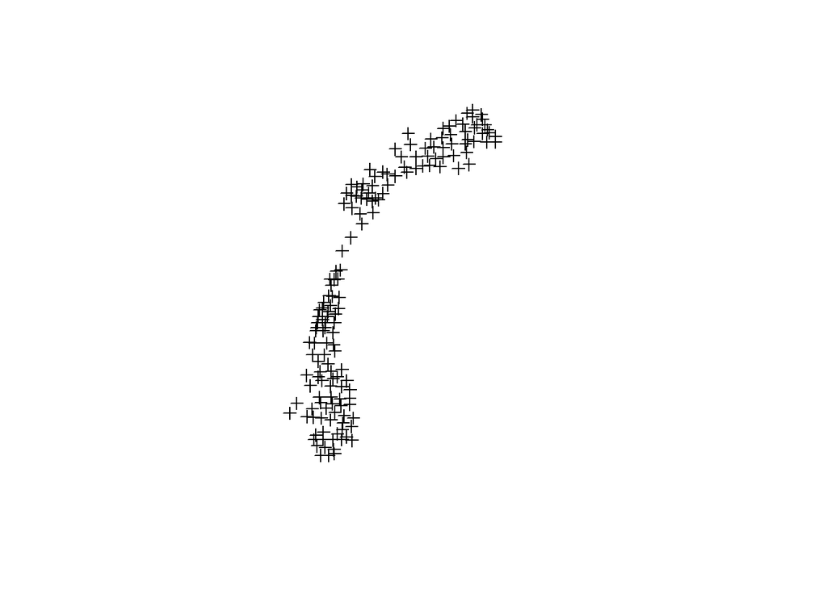

```r
Beob <- spTransform(Beob, CRS(projection(landsat_Kanal3)))
Beob.Punkte <- Beob
plot(Beob.Punkte)
plot(Beob)
```

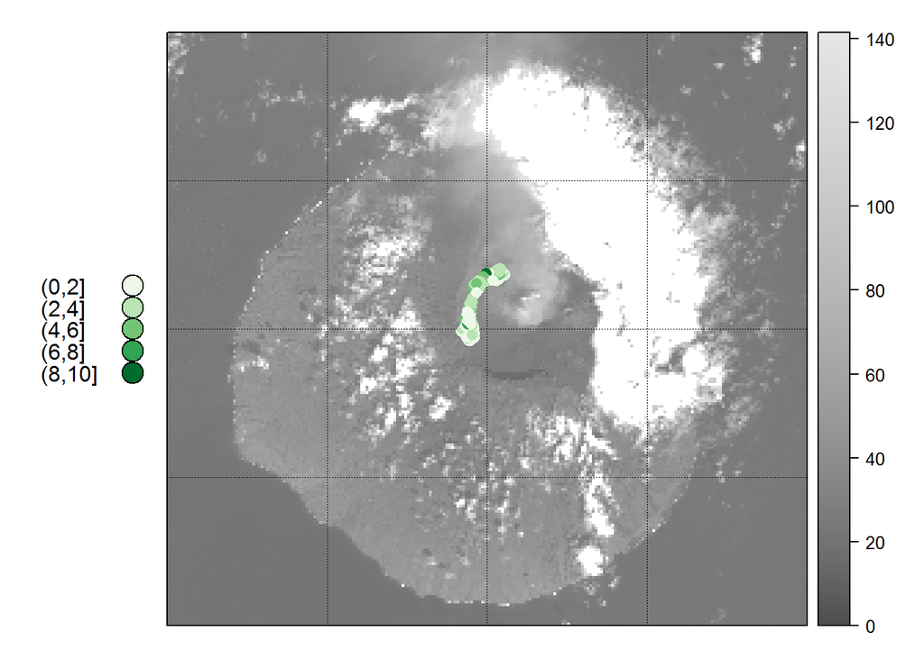

```r
visualizer(landsat_Kanal3, Beob.Punkte, "Greens",5)
```

Well done! :) You stretched the colors and added a spatial point vector attribute